# Report

скачиваем библиотеки

```python
!pip install lxml
!pip install lightgbm
!pip install phik
!pip install pandas
!pip install numpy
!pip install seaborn
!pip install matplotlib
!pip install sklearn
!pip install phik
!pip install random
!pip install -U scikit-learn
!pip install nltk
!pip install missingno
!pip install phik
```

[output not shown]

Импортируем библиотеки

```python
from tqdm.notebook import tqdm
import seaborn as sns
import matplotlib.pyplot as plt
import missingno as msno
from phik.report import plot_correlation_matrix
import pandas as pd
from sklearn import preprocessing
```

# 1.1 Предобработка данных и выделение значимых атрибутов

Задаем данные в переменную df

```python
# Прочитать HTML и создать DataFrame
df = pd.read_html('Выгрузка.csv')[1]

# Вывести DataFrame
df.head()
```

|  | № п/п | № документа | Дата регистрации | Исх. № Дата | Адресат | Автор | Краткое содержание | Примечание |
| --- | --- | --- | --- | --- | --- | --- | --- | --- |
| 0 | 1 | WSR/1-838/2019 | 09.04.2019 | 208-409 08.04.2019 | Уразов Р.Н. | Антонова С.В. (АО «Интерфакс») | Вх - О возможности использования сетевого изда... | NaN |
| 1 | 2 | WSR/1-837/2019 | 09.04.2019 | 05-338 09.04.2019 | Уразов Р.Н. | Картошкин С.А. (Министерство просвещения Росси... | Вх - Об участии в совещании по вопросу доработ... | NaN |
| 2 | 3 | WSR/1-835/2019 | 09.04.2019 | И10-14/3137 09.04.2019 | Уразов Р.Н. | Цивилев С.Е. (Администрация Кемеровской области) | Вх - О командировании Саликовой К. и Глушко Д.... | NaN |
| 3 | 4 | WSR/1-834/2019 | 09.04.2019 | Д2/7121-ИС 03.04.2019 | Иванюк Л.А. | Волков Г.А. (Министерство транспорта Российско... | Вх - Об участии в Чемпионате мира по профессио... | NaN |
| 4 | 5 | WSR/1-833/2019 | 09.04.2019 | 15-20/06-911 08.04.2019 | Уразов Р.Н. | Атанов И.В. (Ставропольский государственный аг... | Вх - Об участии в церемонии открытия Вузовског... | NaN |

смотрим на пропуски данных

```python
df.info()
```

```
<class 'pandas.core.frame.DataFrame'>
RangeIndex: 4967 entries, 0 to 4966
Data columns (total 8 columns):
 #   Column              Non-Null Count  Dtype
---  ------              --------------  -----
 0   № п/п               4967 non-null   int64
 1   № документа         4965 non-null   object
 2   Дата регистрации    4965 non-null   object
 3   Исх. № Дата         4967 non-null   object
 4   Адресат             4967 non-null   object
 5   Автор               4967 non-null   object
 6   Краткое содержание  4967 non-null   object
 7   Примечание          308 non-null    object
dtypes: int64(1), object(7)
memory usage: 310.6+ KB
```

Из этого видно что большинство данных недостает в колонке 'Премечание'

Пеперекодируем данные с помощью LabelEncoder(LabelEncoder намного лушче справляеться с данными чем onehot кодировка)

```python
# и возвращает обновленный DataFrame и сами кодировщики.
def number_encode_features(init_df):
    result = init_df.copy() # копируем нашу исходную таблицу
    encoders = {}
    for column in result.columns:
        if result.dtypes[column] == object: # np.object -- строковый тип / если тип столбца - строка, то нужно его закодировать
            encoders[column] = preprocessing.LabelEncoder() # для колонки column создаем кодировщик
            result[column] = encoders[column].fit_transform(result[column]) # применяем кодировщик к столбцу и перезаписываем столбец
    return result, encoders

encoded_data, encoders = number_encode_features(df) # Теперь encoded data содержит закодированные кат. признаки
encoded_data.head()
```

|  | № п/п | № документа | Дата регистрации | Исх. № Дата | Адресат | Автор | Краткое содержание | Примечание |
| --- | --- | --- | --- | --- | --- | --- | --- | --- |
| 0 | 1 | 3435 | 96 | 2117 | 143 | 85 | 262 | 245 |
| 1 | 2 | 3434 | 96 | 850 | 143 | 724 | 2864 | 245 |
| 2 | 3 | 3430 | 96 | 4057 | 143 | 1827 | 544 | 245 |
| 3 | 4 | 3428 | 96 | 3981 | 48 | 313 | 2609 | 245 |
| 4 | 5 | 3426 | 96 | 1727 | 143 | 113 | 2971 | 245 |

Строим тепловую визуализацию чтобы посмотреть корреляцию

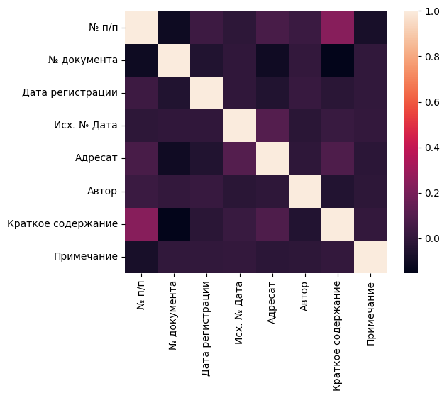

```python
sns.heatmap(encoded_data.corr(), square=True)
plt.show()
```

из этой визулизации видно что наиболее коррелируемым атрибутами является краткое содержание и №п/п и многое другое

удаляем столбцы 'Примечание', '№ п/п', 'Исх. № Дата' из за ненадобности и ненужных данных которые нам не нужны для будующих сессий

Мы оставляем атрибуты '№ документа' 'Дата регистрации' 'Адресат' 'Автор' 'Краткое содержание' ведь они не пустые и могут пригодиться нам в будущем

```python
data = df.drop(columns=['Примечание', '№ п/п', 'Исх. № Дата'])
data.head()
```

|  | № документа | Дата регистрации | Адресат | Автор | Краткое содержание |
| --- | --- | --- | --- | --- | --- |
| 0 | WSR/1-838/2019 | 09.04.2019 | Уразов Р.Н. | Антонова С.В. (АО «Интерфакс») | Вх - О возможности использования сетевого изда... |
| 1 | WSR/1-837/2019 | 09.04.2019 | Уразов Р.Н. | Картошкин С.А. (Министерство просвещения Росси... | Вх - Об участии в совещании по вопросу доработ... |
| 2 | WSR/1-835/2019 | 09.04.2019 | Уразов Р.Н. | Цивилев С.Е. (Администрация Кемеровской области) | Вх - О командировании Саликовой К. и Глушко Д.... |
| 3 | WSR/1-834/2019 | 09.04.2019 | Иванюк Л.А. | Волков Г.А. (Министерство транспорта Российско... | Вх - Об участии в Чемпионате мира по профессио... |
| 4 | WSR/1-833/2019 | 09.04.2019 | Уразов Р.Н. | Атанов И.В. (Ставропольский государственный аг... | Вх - Об участии в церемонии открытия Вузовског... |

Колонки удалились правильно

# 1.2 Разбиение сложных атрибутов

Разбиваем № документа' на 'тип документа', 'номер документа','дата документа'

```python
data[['тип документа', 'номер документа','дата документа']] = data['№ документа'].str.split('/', expand=True)

# Displaying the modified DataFrame
data
```

|  | № документа | Дата регистрации | Адресат | Автор | Краткое содержание | тип документа | номер документа | дата документа |
| --- | --- | --- | --- | --- | --- | --- | --- | --- |
| 0 | WSR/1-838/2019 | 09.04.2019 | Уразов Р.Н. | Антонова С.В. (АО «Интерфакс») | Вх - О возможности использования сетевого изда... | WSR | 1-838 | 2019 |
| 1 | WSR/1-837/2019 | 09.04.2019 | Уразов Р.Н. | Картошкин С.А. (Министерство просвещения Росси... | Вх - Об участии в совещании по вопросу доработ... | WSR | 1-837 | 2019 |
| 2 | WSR/1-835/2019 | 09.04.2019 | Уразов Р.Н. | Цивилев С.Е. (Администрация Кемеровской области) | Вх - О командировании Саликовой К. и Глушко Д.... | WSR | 1-835 | 2019 |
| 3 | WSR/1-834/2019 | 09.04.2019 | Иванюк Л.А. | Волков Г.А. (Министерство транспорта Российско... | Вх - Об участии в Чемпионате мира по профессио... | WSR | 1-834 | 2019 |
| 4 | WSR/1-833/2019 | 09.04.2019 | Уразов Р.Н. | Атанов И.В. (Ставропольский государственный аг... | Вх - Об участии в церемонии открытия Вузовског... | WSR | 1-833 | 2019 |
| ... | ... | ... | ... | ... | ... | ... | ... | ... |
| 4962 | WSR/1.-1749/2017 | 01.11.2017 | Уразов Р.Н. | Медведев Д.А. (Аппарат Правительства Российско... | Протокол заседания Президиума Совета при Прези... | WSR | 1.-1749 | 2017 |
| 4963 | WSR/1.-1751/2017 | 01.11.2017 | Уразов Р.Н. | Синюгина Т.Ю. (Министерство образования и наук... | О проведении 21.11.2017 заседания организацион... | WSR | 1.-1751 | 2017 |
| 4964 | WSR/1.-1748/2017 | 01.11.2017 | Уразов Р.Н. | Огородова Л.М. (Министерство образования и нау... | Протокол заседания рабочей группы приоритетног... | WSR | 1.-1748 | 2017 |
| 4965 | WSR/1.-1747/2017 | 01.11.2017 | Уразов Р.Н. | Огородова Л.М. (Министерство образования и нау... | Протокол заседания рабочей группы приоритетног... | WSR | 1.-1747 | 2017 |
| 4966 | NaN | NaN | Уразов Р.Н. | Асаул Н.А. (Министерство транспорта Российской... | Участие в Чемпионате WorldSkills Hi-Tech Екате... | NaN | NaN | NaN |

4967 rows × 8 columns

После этого удаляем колонку № документа

```python
data = data
data = data.drop('№ документа', axis=1)
data.head()
```

|  | Дата регистрации | Адресат | Автор | Краткое содержание | тип документа | номер документа | дата документа |
| --- | --- | --- | --- | --- | --- | --- | --- |
| 0 | 09.04.2019 | Уразов Р.Н. | Антонова С.В. (АО «Интерфакс») | Вх - О возможности использования сетевого изда... | WSR | 1-838 | 2019 |
| 1 | 09.04.2019 | Уразов Р.Н. | Картошкин С.А. (Министерство просвещения Росси... | Вх - Об участии в совещании по вопросу доработ... | WSR | 1-837 | 2019 |
| 2 | 09.04.2019 | Уразов Р.Н. | Цивилев С.Е. (Администрация Кемеровской области) | Вх - О командировании Саликовой К. и Глушко Д.... | WSR | 1-835 | 2019 |
| 3 | 09.04.2019 | Иванюк Л.А. | Волков Г.А. (Министерство транспорта Российско... | Вх - Об участии в Чемпионате мира по профессио... | WSR | 1-834 | 2019 |
| 4 | 09.04.2019 | Уразов Р.Н. | Атанов И.В. (Ставропольский государственный аг... | Вх - Об участии в церемонии открытия Вузовског... | WSR | 1-833 | 2019 |

Видим что данные разделились правильно

# 1.3 Дополнение недостающими данными

Дополним данные значениями рядом

```python
data = data.fillna(method ='pad')
data
```

|  | Дата регистрации | Адресат | Автор | Краткое содержание | тип документа | номер документа | дата документа |
| --- | --- | --- | --- | --- | --- | --- | --- |
| 0 | 09.04.2019 | Уразов Р.Н. | Антонова С.В. (АО «Интерфакс») | Вх - О возможности использования сетевого изда... | WSR | 1-838 | 2019 |
| 1 | 09.04.2019 | Уразов Р.Н. | Картошкин С.А. (Министерство просвещения Росси... | Вх - Об участии в совещании по вопросу доработ... | WSR | 1-837 | 2019 |
| 2 | 09.04.2019 | Уразов Р.Н. | Цивилев С.Е. (Администрация Кемеровской области) | Вх - О командировании Саликовой К. и Глушко Д.... | WSR | 1-835 | 2019 |
| 3 | 09.04.2019 | Иванюк Л.А. | Волков Г.А. (Министерство транспорта Российско... | Вх - Об участии в Чемпионате мира по профессио... | WSR | 1-834 | 2019 |
| 4 | 09.04.2019 | Уразов Р.Н. | Атанов И.В. (Ставропольский государственный аг... | Вх - Об участии в церемонии открытия Вузовског... | WSR | 1-833 | 2019 |
| ... | ... | ... | ... | ... | ... | ... | ... |
| 4962 | 01.11.2017 | Уразов Р.Н. | Медведев Д.А. (Аппарат Правительства Российско... | Протокол заседания Президиума Совета при Прези... | WSR | 1.-1749 | 2017 |
| 4963 | 01.11.2017 | Уразов Р.Н. | Синюгина Т.Ю. (Министерство образования и наук... | О проведении 21.11.2017 заседания организацион... | WSR | 1.-1751 | 2017 |
| 4964 | 01.11.2017 | Уразов Р.Н. | Огородова Л.М. (Министерство образования и нау... | Протокол заседания рабочей группы приоритетног... | WSR | 1.-1748 | 2017 |
| 4965 | 01.11.2017 | Уразов Р.Н. | Огородова Л.М. (Министерство образования и нау... | Протокол заседания рабочей группы приоритетног... | WSR | 1.-1747 | 2017 |
| 4966 | 01.11.2017 | Уразов Р.Н. | Асаул Н.А. (Министерство транспорта Российской... | Участие в Чемпионате WorldSkills Hi-Tech Екате... | WSR | 1.-1747 | 2017 |

4967 rows × 7 columns

```python
data.info()
```

```
<class 'pandas.core.frame.DataFrame'>
RangeIndex: 4967 entries, 0 to 4966
Data columns (total 7 columns):
 #   Column              Non-Null Count  Dtype
---  ------              --------------  -----
 0   Дата регистрации    4967 non-null   object
 1   Адресат             4967 non-null   object
 2   Автор               4967 non-null   object
 3   Краткое содержание  4967 non-null   object
 4   тип документа       4967 non-null   object
 5   номер документа     4967 non-null   object
 6   дата документа      4967 non-null   object
dtypes: object(7)
memory usage: 271.8+ KB
```

Данные заполнены

# 1.4 Формирование словарей данных

Импортируем библиотеку nltk и скачиваем stopworlds и punkt для словоря данных

```python
import nltk
nltk.download('stopwords')
nltk.download('punkt')
```

```
True
```

пишем код для ключевых слов

```python
import nltk
from nltk.corpus import stopwords
from nltk.tokenize import word_tokenize

stop_words = set(stopwords.words('russian'))  # установите язык, соответствующий вашим данным

keywords = []

for text in data['Краткое содержание']:  # замените 'column_name' на имя вашей колонки
    tokens = word_tokenize(text)
    keywords.extend([word for word in tokens if word.lower() not in stop_words])
```

смотрим на эти слова

```python
print(keywords)
```

[output not shown]

# 1.5 Преобразование списков переадресаций

смотрим на значения

```python
data['Адресат'].unique()
```

```
array(['Уразов Р.Н.', 'Иванюк Л.А.', 'Миронова С.В.', 'Тымчиков А.Ю.',
       'Крайчинская С.Б.', 'Антонов Ю.В.', 'Глушко Д.Е.', 'Аштаева К.Д.',
       'Митькина А.Н.', 'Желковский И.И.', 'Митяева И.В.',
       'Мухаметзянов Д.Ф.', 'Недоспасова О.В. Никул Е.В.',
       'Саликова К.В.', 'Куколев С.В.',
       'Носков К.Ю. Попова А.Ю. Кочнев Д.В. Алешин А.В. Колобков П.А. Колокольцев В.А. Золотов В.В. Булавин В.И. Бортников А.В. Чайка Ю.Я. Скворцова В.И. Зиничев Е.Н. Шойгу С.К. Васильева О.Ю. Дитрих Е.И. Кобылкин Д.Н. Уразов Р.Н. Нарышкин С.Е. Нерадько А.В. Чиханчин Ю.А. Кудрин А.Л. Лавров С.В Баст…
       'Гонтарь М.А.', 'Недоспасова О.В.', 'Глушко Д.Е. Тымчиков А.Ю.',
       'Глушко Д.Е. Иванюк Л.А.', 'Митькина А.Н. Миронова С.В.',
       'Серафимова О.В.', 'Селукова А.И.', 'Зайчикова И.А.',
       'Зензинова К.В.', 'Кожевникова Е.И.', 'Базер О.Э.',
       'Митяева И.В. Крайчинская С.Б.', 'Досканова А.В.',
       'Вишнякова О.Б.', 'Никул Е.В.', 'Алимов А.А.', 'Уфимцев Д.А.',
       'Судаков К.Ю.', 'Митяева И.В. Судаков К.Ю.', 'Лошкарева Е.П.',
       'Гревцов А.Б. Шайхутдинов Р.А. Сафаров А.А. Абдулганиев Ф.С. Гайзатуллин Р.Р. Загидуллин Р.И. Ахметов М.Г. Хамаев А.К. Аюпова И.Х. Сафин Л.Р. Бурганов Р.Т. Зарипова Э.А. Хохорин А.В. Садыков М.Н. Файзуллин И.Э. Каримов А.А. Хабибуллин Р.З. Шадриков А.В. Фаттахов Д.И. Леонов В.А. Кузюров Р.А. …
       'Гафуров И.Р. Каримов А.А. Абдулганиев Ф.С. Леонов В.А. Зарипова Э.А. Фаттахов Д.И. Мухаметшин Р.М. Едиханов Р.А. Газизов А.Х. Агеев Ш.Р. Уразов Р.Н. Шагимарданов А.Р Гараев З.Ф. Юсупов И.У. Гатауллин А.Э. Кабиров Р.Х. Валеев Д.Р. Закиров А.Ф. Шакиров Р.А. Галиуллин Р.Ф. Абдулгалеев З.Т. Сали…
       'Тымчиков А.Ю. Куколев С.В. Узалукова А.В.',
       'Глушко Д.Е. Барышева Т.Г.', 'Иванюк Л.А. Митькина А.Н.',
       'Митькина А.Н. Иванюк Л.А.', 'Попова Я.Д.',
       'Глушко Д.Е. Кожевникова Е.И.', 'Трофимов А.В.',
       'Миронова С.В. Иванюк Л.А.', 'Дубицкая Ю.А.',
       'Тымчиков А.Ю. Глушко Д.Е.', 'Дмитриев М.Г.', 'Тунина К.В.',
       'Терентьев А.М. Шайхутдинов Р.А. Гайзатуллин Р.Р. Бурганов Р.Т. Кадыров А.Р. Уразов Р.Н. Хамитов Д.Г. Хохорин А.В. Гумеров Р.Ф. Мавликов А.В. Гафуров И.Р. Рахимов И.С. Губайдуллин Э.Ф. Зарипова Э.А. Файзуллин И.Э. Каримов А.А. Ахметов М.Г. Иванов С.Е. Садыков М.Н. Аюпова И.Х. Абдулганиев Ф.С.…
       'Недоспасова О.В. Митяева И.В.',
       'Уразов Р.Н. Богучарская А.С. Кожевникова Е.И. Никул Е.В. Софронова М.И. Стогов Е.А. Федосеев А.И.',
       'Уразов Р.Н. Терентьев А.М.', 'Крук С.В.',
       'Глушко Д.Е. Досканова А.В.', 'Иванюк Л.А. Тымчиков А.Ю.',
       'Шайхутдинов Р.А. Бурганов Р.Т. Уразов Р.Н. Нигматуллин Р.К. Юшко С.В. Хусаинов А.Ш. Ларионова Т.П. Камалетдинова Т.С. Шагивалеев Т.Н. Абдулганиев Ф.С. Шайхутдинов Х.Х. Абдуллазянов Э.Ю. Камалтынов Ю.З.',
       'Глушко Д.Е. Недоспасова О.В.', 'Кононова Н.А.',
       'Кононова Н.А. Никул Е.В.',
       'Сафаров А.А. Песошин А.В. Гайзатуллин Р.Р. Шайхутдинов Р.А. Мухаметшин Ф.Х. Хохорин А.В. Леонов В.А. Фаттахов Д.И. Садыков М.Н. Аюпова И.Х. Бурганов Р.Т. Файзуллин И.Э. Каримов А.А. Сафин Л.Р. Абдулганиев Ф.С. Загидуллин Р.И. Руководство Иванов С.Е. Губайдуллин Э.С. Абязова Ю.А. Зарипов А.Р.…
       'Говорова Н.В.', 'Никул Е.В. Кононова Н.А.', 'Барышева Т.Г.',
       'Лысова С.И.', 'Никул Е.В. Гонтарь М.А.',
       'Тымчиков А.Ю. Никул Е.В.', 'Крайчинская С.Б. Федосеев А.И.',
       'Гафуров И.Р. Лаврентьев А.П. Агеев Ш.Р. Афанасьев А.И. Бариев М.М. Залялова А.Г. Вахитов Р.Р. Гайнутдинов А.Р. Гаязов З.Ф. Гильмутдинов И.И. Хамитов Д.Г. Когогин С.А. Афанасьев М.П. Мавликов А.В. Мифтахов Р.З. Маганов Н.У. Павлова О.И. Патяшина М.А. Пустовгаров Ю.Л. Рахимов И.С. Уразов Р.Н. …
       'Глушко Д.Е. Лысова С.И.', 'Лисова Т.А.',
       'Митяева И.В. Никул Е.В.', 'Глушко Д.Е. Никул Е.В.',
       'Бородин И.С.', 'Мухаметзянов Д.Ф. Лысова С.И.', 'Федосеев А.И.',
       'Лысова С.И. Тымчиков А.Ю.', 'Иванюк Л.А. Крайчинская С.Б.',
       'Суперекин И.Ю.', 'Никул Е.В. Глушко Д.Е.',
       'Щугорев Н.А. Саликова К.В.', 'Глушко Д.Е. Базер О.Э.',
```

[output cut: 38 more lines]

```
       'Чуева А.В.', 'Артемова Т.В.', 'Куколев С.В. Судаков К.Ю.',
       'Дрокин В.И. Бакова Ю.В.',
       'Досканова А.В. Глушко Д.Е. Тымчиков А.Ю.',
       'Саликова К.В. Митькина А.Н.', 'Уразов Р.Н. Песков Д.Н.',
       'Уразов Р.Н. Дмитриев М.Г.', 'Уразов Р.Н. Глушко Д.Е.',
       'Глушко Д.Е. Суперекин И.Ю.', 'Лысова С.И. Судаков К.Ю.',
       'Огородова Л.М. Крайчинская С.Б.',
       'Кадылева Ж.М. Овчинников А.Ю. Картошкин С.А. Никул Е.В.',
       'Мухаметзянов Д.Ф. Судаков К.Ю.',
       'Уразов Р.Н. Тымчиков А.Ю. Колусенко У.Д.',
       'Глушко Д.Е. Митькина А.Н.',
       'Уразов Р.Н. Глушко Д.Е. Шабельников С.Н.',
       'Уразов Р.Н. Скидков Я.Р.', 'Осадчая И.В.',
       'Картошкин С.А. Никул Е.В. Овчинников А.Ю. Кадылева Ж.М.'],
      dtype=object)
```

задаем в da наш dataframe на всякий случай

```python
da = data
da
```

|  | Дата регистрации | Адресат | Автор | Краткое содержание | тип документа | номер документа | дата документа |
| --- | --- | --- | --- | --- | --- | --- | --- |
| 0 | 09.04.2019 | Уразов Р.Н. | Антонова С.В. (АО «Интерфакс») | Вх - О возможности использования сетевого изда... | WSR | 1-838 | 2019 |
| 1 | 09.04.2019 | Уразов Р.Н. | Картошкин С.А. (Министерство просвещения Росси... | Вх - Об участии в совещании по вопросу доработ... | WSR | 1-837 | 2019 |
| 2 | 09.04.2019 | Уразов Р.Н. | Цивилев С.Е. (Администрация Кемеровской области) | Вх - О командировании Саликовой К. и Глушко Д.... | WSR | 1-835 | 2019 |
| 3 | 09.04.2019 | Иванюк Л.А. | Волков Г.А. (Министерство транспорта Российско... | Вх - Об участии в Чемпионате мира по профессио... | WSR | 1-834 | 2019 |
| 4 | 09.04.2019 | Уразов Р.Н. | Атанов И.В. (Ставропольский государственный аг... | Вх - Об участии в церемонии открытия Вузовског... | WSR | 1-833 | 2019 |
| ... | ... | ... | ... | ... | ... | ... | ... |
| 4962 | 01.11.2017 | Уразов Р.Н. | Медведев Д.А. (Аппарат Правительства Российско... | Протокол заседания Президиума Совета при Прези... | WSR | 1.-1749 | 2017 |
| 4963 | 01.11.2017 | Уразов Р.Н. | Синюгина Т.Ю. (Министерство образования и наук... | О проведении 21.11.2017 заседания организацион... | WSR | 1.-1751 | 2017 |
| 4964 | 01.11.2017 | Уразов Р.Н. | Огородова Л.М. (Министерство образования и нау... | Протокол заседания рабочей группы приоритетног... | WSR | 1.-1748 | 2017 |
| 4965 | 01.11.2017 | Уразов Р.Н. | Огородова Л.М. (Министерство образования и нау... | Протокол заседания рабочей группы приоритетног... | WSR | 1.-1747 | 2017 |
| 4966 | 01.11.2017 | Уразов Р.Н. | Асаул Н.А. (Министерство транспорта Российской... | Участие в Чемпионате WorldSkills Hi-Tech Екате... | WSR | 1.-1747 | 2017 |

4967 rows × 7 columns

Разделяем колонку Адресат и берем последние значения и соеденяем их

```python
da["Главный Адресат"] = da['Адресат'].str.split().str[-2]
da["1 Адресат"] = da['Адресат'].str.split().str[-1]
da['главный Адресат'] = da['Главный Адресат'] + ' ' + da['1 Адресат']
data = da.drop(columns=['Главный Адресат', '1 Адресат','Адресат'])
data.head()
data
```

|  | Дата регистрации | Автор | Краткое содержание | тип документа | номер документа | дата документа | главный Адресат |
| --- | --- | --- | --- | --- | --- | --- | --- |
| 0 | 09.04.2019 | Антонова С.В. (АО «Интерфакс») | Вх - О возможности использования сетевого изда... | WSR | 1-838 | 2019 | Уразов Р.Н. |
| 1 | 09.04.2019 | Картошкин С.А. (Министерство просвещения Росси... | Вх - Об участии в совещании по вопросу доработ... | WSR | 1-837 | 2019 | Уразов Р.Н. |
| 2 | 09.04.2019 | Цивилев С.Е. (Администрация Кемеровской области) | Вх - О командировании Саликовой К. и Глушко Д.... | WSR | 1-835 | 2019 | Уразов Р.Н. |
| 3 | 09.04.2019 | Волков Г.А. (Министерство транспорта Российско... | Вх - Об участии в Чемпионате мира по профессио... | WSR | 1-834 | 2019 | Иванюк Л.А. |
| 4 | 09.04.2019 | Атанов И.В. (Ставропольский государственный аг... | Вх - Об участии в церемонии открытия Вузовског... | WSR | 1-833 | 2019 | Уразов Р.Н. |
| ... | ... | ... | ... | ... | ... | ... | ... |
| 4962 | 01.11.2017 | Медведев Д.А. (Аппарат Правительства Российско... | Протокол заседания Президиума Совета при Прези... | WSR | 1.-1749 | 2017 | Уразов Р.Н. |
| 4963 | 01.11.2017 | Синюгина Т.Ю. (Министерство образования и наук... | О проведении 21.11.2017 заседания организацион... | WSR | 1.-1751 | 2017 | Уразов Р.Н. |
| 4964 | 01.11.2017 | Огородова Л.М. (Министерство образования и нау... | Протокол заседания рабочей группы приоритетног... | WSR | 1.-1748 | 2017 | Уразов Р.Н. |
| 4965 | 01.11.2017 | Огородова Л.М. (Министерство образования и нау... | Протокол заседания рабочей группы приоритетног... | WSR | 1.-1747 | 2017 | Уразов Р.Н. |
| 4966 | 01.11.2017 | Асаул Н.А. (Министерство транспорта Российской... | Участие в Чемпионате WorldSkills Hi-Tech Екате... | WSR | 1.-1747 | 2017 | Уразов Р.Н. |

4967 rows × 7 columns

проверяем заново

```python
data['главный Адресат'].unique()
```

```
array(['Уразов Р.Н.', 'Иванюк Л.А.', 'Миронова С.В.', 'Тымчиков А.Ю.',
       'Крайчинская С.Б.', 'Антонов Ю.В.', 'Глушко Д.Е.', 'Аштаева К.Д.',
       'Митькина А.Н.', 'Желковский И.И.', 'Митяева И.В.',
       'Мухаметзянов Д.Ф.', 'Никул Е.В.', 'Саликова К.В.', 'Куколев С.В.',
       'Коновалов А.В.', 'Гонтарь М.А.', 'Недоспасова О.В.',
       'Серафимова О.В.', 'Селукова А.И.', 'Зайчикова И.А.',
       'Зензинова К.В.', 'Кожевникова Е.И.', 'Базер О.Э.',
       'Досканова А.В.', 'Вишнякова О.Б.', 'Алимов А.А.', 'Уфимцев Д.А.',
       'Судаков К.Ю.', 'Лошкарева Е.П.', 'Шафигуллин Л.Н.',
       'Аблязов К.А.', 'Узалукова А.В.', 'Барышева Т.Г.', 'Попова Я.Д.',
       'Трофимов А.В.', 'Дубицкая Ю.А.', 'Дмитриев М.Г.', 'Тунина К.В.',
       'Губайдуллин Э.Ф.', 'Федосеев А.И.', 'Терентьев А.М.', 'Крук С.В.',
       'Камалтынов Ю.З.', 'Кононова Н.А.', 'Хамаев А.К.', 'Говорова Н.В.',
       'Лысова С.И.', 'Якубов Ю.Д.', 'Лисова Т.А.', 'Бородин И.С.',
       'Суперекин И.Ю.', 'Езерская А.М.', 'Хворостяная И.В.',
       'Сумакова Е.Д.', 'Покровская И.В.', 'Бакова Ю.В.', 'Кадыров А.Р.',
       'Стеклова И.В.', 'Смирнова Л.В.', 'Плюмпа М.А.',
       'Безносикова Н.А.', 'Мартынюк Е.Д.', 'Домаева О.Ю.',
       'Степаненко Е.А.', 'Токтарова Т.А.', 'Абдуллин А.М.',
       'Гайдаев М.И.', 'Багров Ю.Н.', 'Акимов П.М.', 'Тарасенко М.Е.',
       'Набатова А.Ю.', 'Нерезькова И.В.', 'Чуева А.В.', 'Артемова Т.В.',
       'Песков Д.Н.', 'Колусенко У.Д.', 'Шабельников С.Н.',
       'Скидков Я.Р.', 'Осадчая И.В.', 'Кадылева Ж.М.'], dtype=object)
```

Данные корректны

# 1.6 Подготовка отчета

В результате этой сессии была выполнена предобработка данных для дальнейшего исследования и построения модели обучения.Данные были разбиены на несколько атрибутов. Был сформирован словарь данных и выполнен отчет.

Дата регистрации - дата регистрации

Автор - автор документа

Краткое содержание - краткое содержание документа

тип документа - тип документа

номер документа - номер документа

дата документа - дата документа

главный Адресат - итоговый получатель

```python
data.to_csv('data.csv',index=False)
```